# Syncom: Initial analysis

Marco Kreuzer

[Interfaculty Bioinformatics Unit (IBU)](https://www.bioinformatics.unibe.ch)  
marco.kreuzer@bioinformatics.unibe.ch

10.09.2021

## 0.1 Workflow

The dada2 pipeline was applied in order to get high-quality 16S sequences from raw reads.

The pipeline consists of the following steps:

1. filtering and trimming of raw reads

```r
filterAndTrim(...,
              maxN=0,
              maxEE=c(2,2),
              trimLeft = 19,
              trimRight = 19,
              truncQ=2,
              rm.phix=TRUE,
        compress=TRUE, multithread=FALSE)
```

2. Learning errors from the quality filtered reads

```r
errF <- learnErrors(..., multithread=TRUE)
errR <- learnErrors(..., multithread=TRUE)
```

The estimations of the error rates looks as expected:

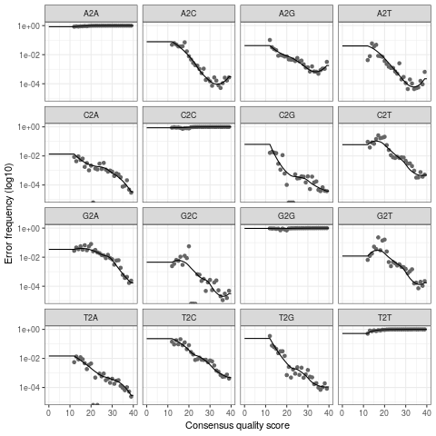

3. The filtered sequences were dereplicated:

```r
derepFs <- derepFastq(..., verbose=TRUE)
```

4. The dada2 algorithm for denoising the reads was applied

```r
 dada(derepFs, err=errF, multithread=TRUE)
```

5. Then the reads pairs were merged

```r
 mergers <- mergePairs(dadaFs, derepFs, dadaRs, derepRs, verbose=TRUE,
                      minOverlap=20)
```

6. Chimeric sequences were removed as follows:

```r
seqtab.nochim <- removeBimeraDenovo(...,
                                    method="consensus",
                                    multithread=TRUE, verbose=TRUE)
```

7. The taxonomy was assigned in two searches against the SILVA database.

Using the “silva_nr_v138_train_set.fa.gz” data for the assignment until genus level.

```r
assignTaxonomy(..., "silva_nr_v138_train_set.fa.gz",
                       multithread=TRUE)
```

```r
addSpecies((..., "silva_species_assignment_v138.fa.gz")
```

8. A phyloseq object with the taxonomy and the counts tables was built.

## 0.2 QC

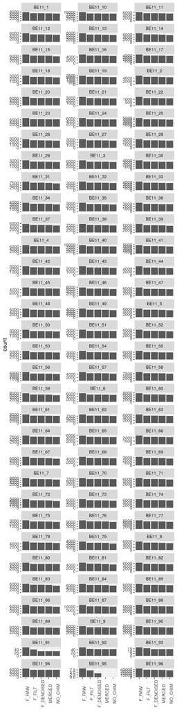

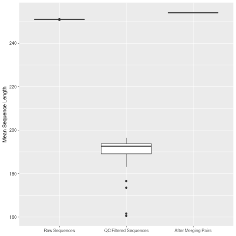

Boxplot of the mean sequence length per sample before and after merging. This is an important validation that the filtering and merging parameters were set correctly.

### 0.2.1 High-level taxonomic comparison between controls and tissue samples

As can be seen in the plot below, only Bacterial reads were amplified.

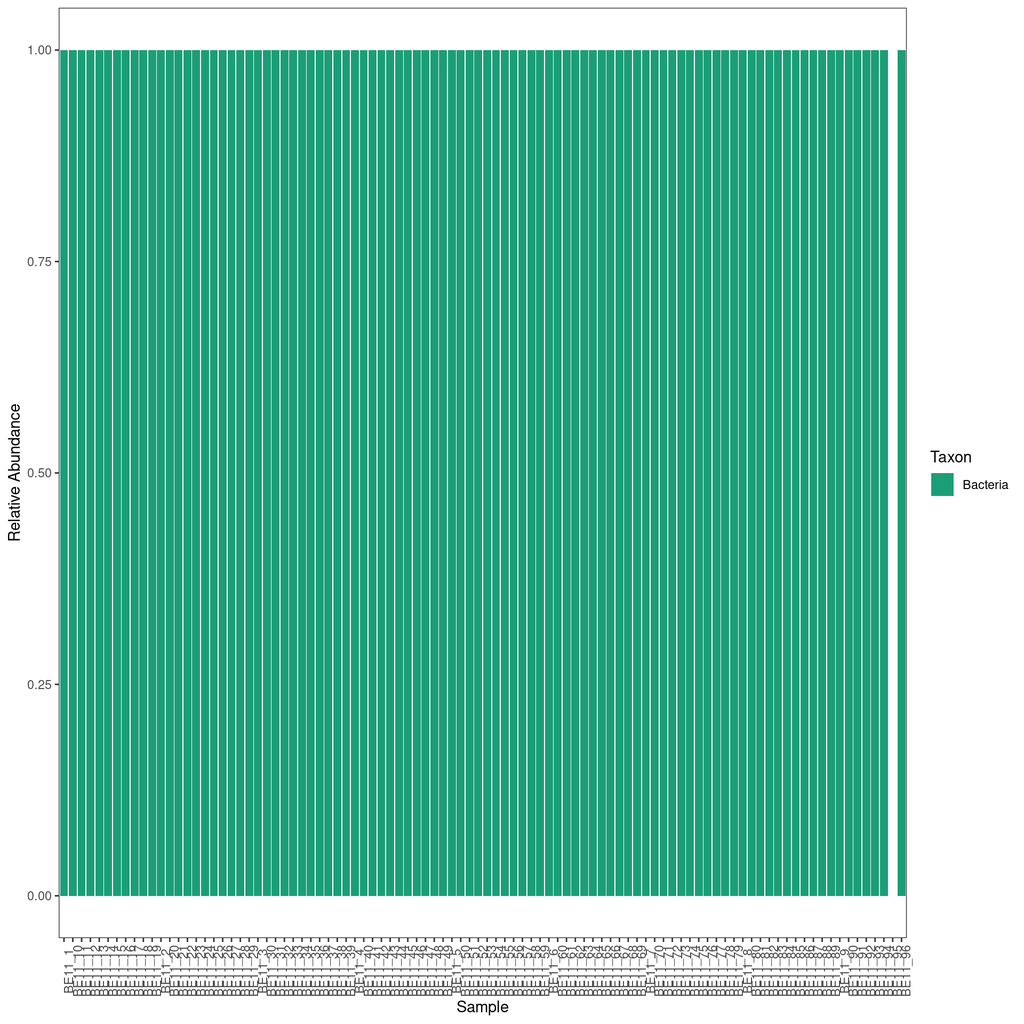

Figure 1: Only Bacterial reads were sequenced

### 0.2.2 Read Track over all barcode combinations sequenced

| Sample | number_of_reads |
| --- | --- |
| BE11_1 | 7806 |
| BE11_2 | 5673 |
| BE11_3 | 6949 |
| BE11_4 | 7459 |
| BE11_5 | 6472 |
| BE11_6 | 6455 |
| BE11_7 | 8148 |
| BE11_8 | 6080 |
| BE11_9 | 8288 |
| BE11_10 | 10229 |
| BE11_11 | 6468 |
| BE11_12 | 6004 |
| BE11_13 | 7845 |
| BE11_14 | 7114 |
| BE11_15 | 7431 |
| BE11_16 | 5624 |
| BE11_17 | 4584 |
| BE11_18 | 3111 |
| BE11_19 | 2462 |
| BE11_20 | 7250 |
| BE11_21 | 3442 |
| BE11_22 | 1383 |
| BE11_23 | 7554 |
| BE11_24 | 6623 |
| BE11_25 | 5019 |
| BE11_26 | 2866 |
| BE11_27 | 3183 |
| BE11_28 | 3029 |
| BE11_29 | 3173 |
| BE11_30 | 3963 |

[output cut: 263 more lines]

## 0.3 Genus-level assignments

The plot below shows the taxonomic assignment on the genus level (no species-level assignments were successfully made).

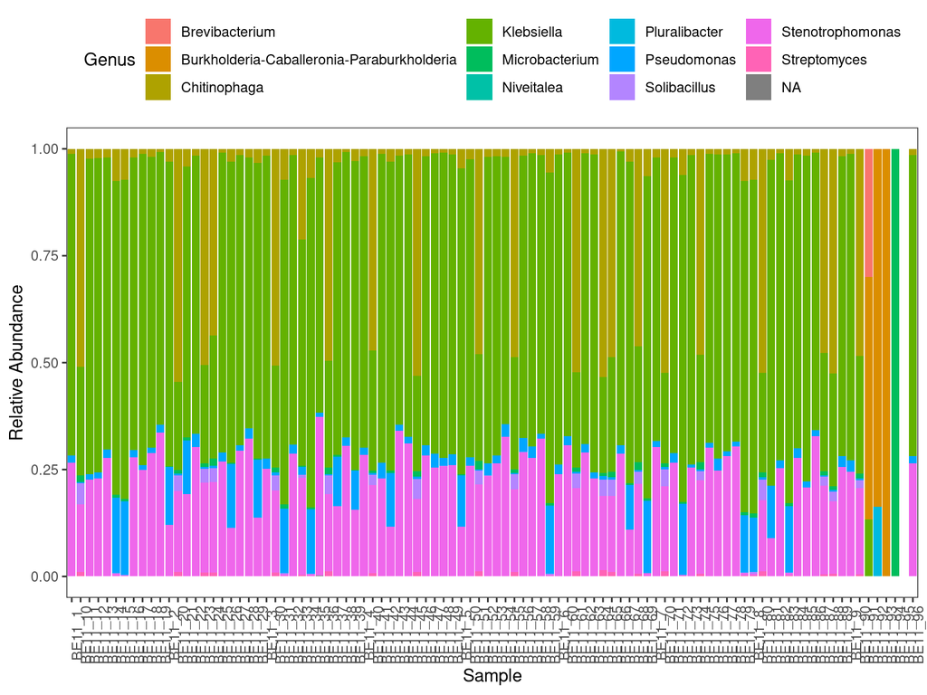

Figure 2: Genus-level assignments